# Ecology - Appendix S2 : Phenotypic plasticity of ‘off-host’ parasite stages in response to heatwaves in the Daphnia-Pasteuria system

## 5. Parasite life-cycle

This section explores how temperature and the genotype of the parasite contribute to the abundance of each stage of the life-cycle after infection, using generalized linear mixed models.

### 5.1 Cauliflowers

Cauliflowers corresponds to the first stage of the parasite life-cycle and here we are interested to understand how their presence/absence is affected by the temperature and/or the genotype of the spores. We also investigated the potential impact of the variations in time post-exposure, as all screened individuals died at different time.

```r
data_c1 = subset(data, data$cauliflowers != "not-well-counted" & data$cauliflowers != "counted-after-freezer" & data$stade_max != "2nd_Cauliflower" & Temperature != "NA")
data_c1$Temperature = factor(data_c1$Temperature, ordered = TRUE)

Caul = glmmTMB(data=data_c1, cauliflowers~Temperature+Isolate+DeathAge, family = "binomial", REML= T)
CaulR = glmmTMB(data=data_c1, cauliflowers~Temperature+Isolate+DeathAge + (1|Batch), family = "binomial", REML= T)

AICc(Caul, CaulR)
```

```
##       df     AICc
## Caul   7 119.6534
## CaulR  8 121.7682
```

```r
Caul1 = glmmTMB(data=data_c1, cauliflowers~Temperature*Isolate*DeathAge, family = "binomial", REML= F)
Caul2 = glmmTMB(data=data_c1, cauliflowers~Temperature+Isolate*DeathAge, family = "binomial", REML= F)
Caul3 = glmmTMB(data=data_c1, cauliflowers~Temperature*Isolate+DeathAge, family = "binomial", REML= F)
Caul4 = glmmTMB(data=data_c1, cauliflowers~Isolate+DeathAge*Temperature, family = "binomial", REML= F)
Caul5 = glmmTMB(data=data_c1, cauliflowers~Isolate*DeathAge, family = "binomial", REML= F)
Caul6 = glmmTMB(data=data_c1, cauliflowers~Temperature*Isolate, family = "binomial", REML= F)
Caul7 = glmmTMB(data=data_c1, cauliflowers~DeathAge*Temperature, family = "binomial", REML= F)
Caul8 = glmmTMB(data=data_c1, cauliflowers~Temperature+Isolate+DeathAge, family = "binomial", REML= F)
Caul9 = glmmTMB(data=data_c1, cauliflowers~Isolate+DeathAge, family = "binomial", REML= F)
Caul10 = glmmTMB(data=data_c1, cauliflowers~Temperature+Isolate, family = "binomial", REML= F)
Caul11 = glmmTMB(data=data_c1, cauliflowers~DeathAge+Temperature, family = "binomial", REML= F)
Caul12 = glmmTMB(data=data_c1, cauliflowers~DeathAge, family = "binomial", REML= F)
Caul13 = glmmTMB(data=data_c1, cauliflowers~Isolate, family = "binomial", REML= F)
Caul14 = glmmTMB(data=data_c1, cauliflowers~Temperature, family = "binomial", REML= F)
Caul0 = glmmTMB(data=data_c1, cauliflowers~1, family = "binomial", REML= F)

AICc(Caul1, Caul2, Caul3, Caul4, Caul5, Caul6, Caul7, Caul8, Caul9, Caul10, Caul11, Caul12, Caul13, Caul14, Caul0)
```

```
##        df     AICc
## Caul1  24       NA
## Caul2  10 121.1953
## Caul3  13 123.4742
## Caul4   9 121.1437
## Caul5   8 121.2525
## Caul6  12 151.2119
## Caul7   6 115.2956
## Caul8   7 116.9950
## Caul9   5 117.3381
## Caul10  6 148.7161
## Caul11  4 111.2346
## Caul12  2 111.9709
## Caul13  4 157.5159
## Caul14  3 144.1507
## Caul0   1 152.8702
```

```r
tab_model(Caul11, Caul12, Caul7, Caul8, Caul5, Caul2, Caul4, show.intercept = F)
```

|  | cauliflowers |  |  | cauliflowers |  |  | cauliflowers |  |  | cauliflowers |  |  | cauliflowers |  |  | cauliflowers |  |  | cauliflowers |  |  |
| --- | --- | --- | --- | --- | --- | --- | --- | --- | --- | --- | --- | --- | --- | --- | --- | --- | --- | --- | --- | --- | --- |
| Predictors | Odds Ratios | CI | p | Odds Ratios | CI | p | Odds Ratios | CI | p | Odds Ratios | CI | p | Odds Ratios | CI | p | Odds Ratios | CI | p | Odds Ratios | CI | p |
| DeathAge | 0.91 | 0.87 – 0.95 | **<0.001** | 0.90 | 0.87 – 0.94 | **<0.001** | 0.91 | 0.87 – 0.95 | **<0.001** | 0.91 | 0.87 – 0.95 | **<0.001** | 0.85 | 0.73 – 1.00 | **0.049** | 0.86 | 0.73 – 1.01 | 0.064 | 0.91 | 0.87 – 0.95 | **<0.001** |
| Temperature [linear] | 0.34 | 0.11 – 1.05 | 0.060 |  |  |  | 0.24 | 0.02 – 3.09 | 0.271 | 0.34 | 0.11 – 1.08 | 0.066 |  |  |  | 0.34 | 0.10 – 1.08 | 0.068 | 0.23 | 0.02 – 3.33 | 0.284 |
| Temperature [quadratic] | 0.97 | 0.36 – 2.57 | 0.944 |  |  |  | 0.84 | 0.08 – 9.24 | 0.886 | 0.96 | 0.36 – 2.57 | 0.940 |  |  |  | 0.94 | 0.35 – 2.51 | 0.895 | 0.81 | 0.07 – 9.22 | 0.866 |
| DeathAge × Temperature [linear] |  |  |  |  |  |  | 1.01 | 0.93 – 1.10 | 0.753 |  |  |  |  |  |  |  |  |  | 1.01 | 0.93 – 1.10 | 0.755 |
| DeathAge × Temperature [quadratic] |  |  |  |  |  |  | 1.00 | 0.92 – 1.09 | 0.911 |  |  |  |  |  |  |  |  |  | 1.01 | 0.92 – 1.10 | 0.890 |
| Isolate [C1] |  |  |  |  |  |  |  |  |  | 0.91 | 0.21 – 3.99 | 0.897 | 0.16 | 0.00 – 12.00 | 0.409 | 0.11 | 0.00 – 9.38 | 0.331 | 0.89 | 0.20 – 3.94 | 0.878 |
| Isolate [C18] |  |  |  |  |  |  |  |  |  | 0.85 | 0.19 – 3.83 | 0.831 | 0.06 | 0.00 – 4.98 | 0.214 | 0.10 | 0.00 – 10.12 | 0.331 | 0.87 | 0.19 – 3.99 | 0.857 |
| Isolate [C24] |  |  |  |  |  |  |  |  |  | 1.33 | 0.34 – 5.16 | 0.683 | 0.91 | 0.01 – 134.04 | 0.969 | 1.02 | 0.01 – 159.66 | 0.994 | 1.34 | 0.34 – 5.23 | 0.676 |
| Isolate [C1] × DeathAge |  |  |  |  |  |  |  |  |  |  |  |  | 1.08 | 0.91 – 1.29 | 0.389 | 1.09 | 0.91 – 1.31 | 0.340 |  |  |  |
| Isolate [C18] × DeathAge |  |  |  |  |  |  |  |  |  |  |  |  | 1.10 | 0.92 – 1.31 | 0.285 | 1.09 | 0.91 – 1.30 | 0.363 |  |  |  |
| Isolate [C24] × DeathAge |  |  |  |  |  |  |  |  |  |  |  |  | 1.02 | 0.82 – 1.25 | 0.886 | 1.01 | 0.82 – 1.25 | 0.899 |  |  |  |
| Observations | 291 |  |  | 291 |  |  | 291 |  |  | 291 |  |  | 291 |  |  | 291 |  |  | 291 |  |  |
| R<sup>2</sup> Tjur | 0.194 |  |  | 0.154 |  |  | 0.197 |  |  | 0.203 |  |  | 0.183 |  |  | 0.220 |  |  | 0.205 |  |  |

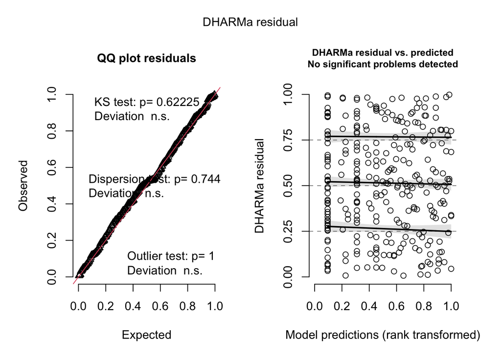

```
## Object of Class DHARMa with simulated residuals based on 250 simulations with refit = FALSE . See ?DHARMa::simulateResiduals for help.
##
## Scaled residual values: 0.3388901 0.3332647 0.415397 0.04419869 0.3642384 0.5669417 0.7992067 0.6843859 0.5363047 0.5255567 0.4620051 0.9983571 0.2413181 0.1928017 0.1345064 0.2465995 0.7431666 0.4926976 0.5356813 0.0344749 ...
```

```r
# No differences

simulateResiduals(Caul11, plot=T)
```

```r
# best model
Caul11 = glmmTMB(data=data_c1, cauliflowers~DeathAge+Temperature, family = "binomial", REML=T)
summary(Caul11)
```

```
##  Family: binomial  ( logit )
## Formula:          cauliflowers ~ DeathAge + Temperature
## Data: data_c1
##
##       AIC       BIC    logLik -2*log(L)  df.resid
##     116.8     131.4     -54.4     108.8       287
##
##
## Conditional model:
##               Estimate Std. Error z value Pr(>|z|)
## (Intercept)    0.66549    0.67120   0.991   0.3214
## DeathAge      -0.09664    0.02279  -4.241 2.23e-05 ***
## Temperature.L -1.08254    0.57628  -1.878   0.0603 .
## Temperature.Q -0.03522    0.49967  -0.070   0.9438
## ---
## Signif. codes:  0 '***' 0.001 '**' 0.01 '*' 0.05 '.' 0.1 ' ' 1
```

```r
tab_model(Caul11, show.intercept = F)
```

|  | cauliflowers |  |  |
| --- | --- | --- | --- |
| Predictors | Odds Ratios | CI | p |
| DeathAge | 0.91 | 0.87 – 0.95 | **<0.001** |
| Temperature [linear] | 0.34 | 0.11 – 1.05 | 0.060 |
| Temperature [quadratic] | 0.97 | 0.36 – 2.57 | 0.944 |
| Observations | 291 |  |  |
| R<sup>2</sup> Tjur | 0.194 |  |  |

We observed that the time post-exposure is reducing of 10% the probability to observe first stage cauliflowers, temperature might have a role that is not significant with the current effective of our experimentation.

#### Visualisation

[figure not shown]

### 5.2 Grape seed stage

The grape seed stage corresponds to the second visible stage of the parasite life cycle and here we are interested in understanding how its presence/absence is affected by temperature and the genotype of the spores. We also investigated the potential impact of variations in time post-exposure, as all screened individuals died at different times.

```r
data_crushed_inf_c = subset(infected, infected$grapes!="counted-after-freezer" & infected$grapes!="counted-after-freezer")

Grap = glmmTMB(data=data_crushed_inf_c, grapes~Temperature+Isolate+DeathAge, family = "binomial", REML=F)
GrapR = glmmTMB(data=data_crushed_inf_c, grapes~Temperature+Isolate+DeathAge+ (1|Batch), family = "binomial", REML=F)

AICc(Grap,GrapR) # No need for random effect
```

```
##       df     AICc
## Grap   7 209.1698
## GrapR  8 210.7109
```

```r
Grap1 = glmmTMB(data=data_crushed_inf_c, grapes~Temperature*Isolate*DeathAge, family = "binomial")
Grap2 = glmmTMB(data=data_crushed_inf_c, grapes~Temperature+Isolate*DeathAge, family = "binomial")
Grap3 = glmmTMB(data=data_crushed_inf_c, grapes~Temperature*Isolate+DeathAge, family = "binomial")
Grap4 = glmmTMB(data=data_crushed_inf_c, grapes~Isolate+DeathAge*Temperature, family = "binomial")

Grap5 = glmmTMB(data=data_crushed_inf_c, grapes~Isolate*DeathAge, family = "binomial")
Grap6 = glmmTMB(data=data_crushed_inf_c, grapes~Temperature*Isolate, family = "binomial")
Grap7 = glmmTMB(data=data_crushed_inf_c, grapes~Temperature*DeathAge, family = "binomial")

Grap8 = glmmTMB(data=data_crushed_inf_c, grapes~Temperature+Isolate+DeathAge, family = "binomial")

Grap9 = glmmTMB(data=data_crushed_inf_c, grapes~Isolate+DeathAge, family = "binomial")
Grap10 = glmmTMB(data=data_crushed_inf_c, grapes~Temperature+Isolate, family = "binomial")
Grap11 = glmmTMB(data=data_crushed_inf_c, grapes~Temperature+DeathAge, family = "binomial")

Grap12 = glmmTMB(data=data_crushed_inf_c, grapes~DeathAge, family = "binomial")
Grap13 = glmmTMB(data=data_crushed_inf_c, grapes~Isolate, family = "binomial")
Grap14 = glmmTMB(data=data_crushed_inf_c, grapes~Temperature, family = "binomial")

Grap0 = glmmTMB(data=data_crushed_inf_c, grapes~1, family = "binomial")

AICc(Grap1, Grap2, Grap3, Grap4, Grap5, Grap6, Grap7, Grap8, Grap9, Grap10, Grap11, Grap12, Grap13, Grap14, Grap0)
```

```
##        df     AICc
## Grap1  24       NA
## Grap2  10 204.7698
## Grap3  13 219.5599
## Grap4   9 212.0557
## Grap5   8 207.6257
## Grap6  12 217.6432
## Grap7   6 206.7304
## Grap8   7 209.1698
## Grap9   5 213.9978
## Grap10  6 207.8652
## Grap11  4 204.1768
## Grap12  2 209.5133
## Grap13  4 213.0738
## Grap14  3 202.8924
## Grap0   1 208.6435
```

```r
tab_model(Grap14, Grap11, Grap10, Grap8, Grap0, show.intercept = F)
```

|  | grapes |  |  | grapes |  |  | grapes |  |  | grapes |  |  | grapes |  |  |
| --- | --- | --- | --- | --- | --- | --- | --- | --- | --- | --- | --- | --- | --- | --- | --- |
| Predictors | Odds Ratios | CI | p | Odds Ratios | CI | p | Odds Ratios | CI | p | Odds Ratios | CI | p | Odds Ratios | CI | p |
| Temperature [linear] | 2.69 | 1.38 – 5.25 | **0.004** | 2.66 | 1.36 – 5.20 | **0.004** | 2.70 | 1.37 – 5.32 | **0.004** | 2.67 | 1.35 – 5.27 | **0.005** |  |  |  |
| Temperature [quadratic] | 1.44 | 0.79 – 2.62 | 0.237 | 1.41 | 0.77 – 2.57 | 0.268 | 1.40 | 0.76 – 2.56 | 0.278 | 1.37 | 0.74 – 2.51 | 0.315 |  |  |  |
| DeathAge |  |  |  | 1.01 | 0.99 – 1.04 | 0.366 |  |  |  | 1.01 | 0.99 – 1.04 | 0.348 |  |  |  |
| Isolate [C1] |  |  |  |  |  |  | 1.76 | 0.63 – 4.89 | 0.281 | 1.84 | 0.65 – 5.18 | 0.249 |  |  |  |
| Isolate [C18] |  |  |  |  |  |  | 1.57 | 0.59 – 4.17 | 0.363 | 1.44 | 0.53 – 3.90 | 0.478 |  |  |  |
| Isolate [C24] |  |  |  |  |  |  | 1.25 | 0.47 – 3.36 | 0.652 | 1.22 | 0.45 – 3.29 | 0.693 |  |  |  |
| Observations | 158 |  |  | 158 |  |  | 158 |  |  | 158 |  |  | 158 |  |  |
| R<sup>2</sup> Tjur | 0.058 |  |  | 0.064 |  |  | 0.068 |  |  | 0.075 |  |  | 0.000 |  |  |

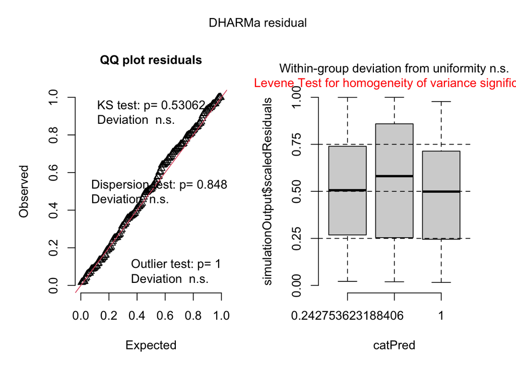

```
## Object of Class DHARMa with simulated residuals based on 250 simulations with refit = FALSE . See ?DHARMa::simulateResiduals for help.
##
## Scaled residual values: 0.7676696 0.05811451 0.2656332 0.3575351 0.9665073 0.3685181 0.7259261 0.04275554 0.06533833 0.1598172 0.02149855 0.8880048 0.4096685 0.3173512 0.08902606 0.6813057 0.1156503 0.1831655 0.3961829 0.6764339 ...
```

```r
# Temperature increase the chances to observe grapes

simulateResiduals(Grap14, plot=T)
```

```r
summary(Grap14)
```

```
##  Family: binomial  ( logit )
## Formula:          grapes ~ Temperature
## Data: data_crushed_inf_c
##
##       AIC       BIC    logLik -2*log(L)  df.resid
##     202.7     211.9     -98.4     196.7       155
##
##
## Conditional model:
##               Estimate Std. Error z value Pr(>|z|)
## (Intercept)     0.7337     0.1873   3.918 8.94e-05 ***
## Temperature.L   0.9886     0.3416   2.894   0.0038 **
## Temperature.Q   0.3618     0.3062   1.182   0.2373
## ---
## Signif. codes:  0 '***' 0.001 '**' 0.01 '*' 0.05 '.' 0.1 ' ' 1
```

```r
tab_model(Grap14, show.intercept = F)
```

|  | grapes |  |  |
| --- | --- | --- | --- |
| Predictors | Odds Ratios | CI | p |
| Temperature [linear] | 2.69 | 1.38 – 5.25 | **0.004** |
| Temperature [quadratic] | 1.44 | 0.79 – 2.62 | 0.237 |
| Observations | 158 |  |  |
| R<sup>2</sup> Tjur | 0.058 |  |  |

We observed that the temperature increases the odds of observing grape stage seeds by 168%.